Tarea 8 - Clasificacion K - means

Por: César Omar López Arteaga

Marzo 2024

# PREGUNTA 1

Bajar el archivo Clase_8.R

**Solucion**

```r
# Análisis con k- means

# Carga de la data Linnerud
linnerud <- read.csv("F:/R IMCA/TAREA 8/DESCARGA_DATA/Linnerud.csv",header=TRUE,row.names=1)

# Verificar la estructura de los datos
str(linnerud)
```

```
## 'data.frame':    20 obs. of  6 variables:
##  $ Peso        : int  191 189 193 162 189 182 211 167 176 154 ...
##  $ Cintura     : int  36 37 38 35 35 36 38 34 31 33 ...
##  $ Pulsaciones : int  50 52 58 62 46 56 56 60 74 56 ...
##  $ Lanzamientos: int  5 2 12 12 13 4 8 6 15 17 ...
##  $ Flexiones   : int  162 110 101 105 155 101 101 125 200 251 ...
##  $ Saltos      : int  60 60 101 37 58 42 38 40 40 250 ...
```

```r
# Visualizar los primeros registros de los datos sin modificar
head(linnerud,n=10)
```

|  | Peso | Cintura | Pulsaciones | Lanzamientos | Flexiones | Saltos |
| --- | --- | --- | --- | --- | --- | --- |
| 1 | 191 | 36 | 50 | 5 | 162 | 60 |
| 2 | 189 | 37 | 52 | 2 | 110 | 60 |
| 3 | 193 | 38 | 58 | 12 | 101 | 101 |
| 4 | 162 | 35 | 62 | 12 | 105 | 37 |
| 5 | 189 | 35 | 46 | 13 | 155 | 58 |
| 6 | 182 | 36 | 56 | 4 | 101 | 42 |
| 7 | 211 | 38 | 56 | 8 | 101 | 38 |
| 8 | 167 | 34 | 60 | 6 | 125 | 40 |
| 9 | 176 | 31 | 74 | 15 | 200 | 40 |
| 10 | 154 | 33 | 56 | 17 | 251 | 250 |

```r
#  inicialización
dat      <- linnerud

#numero de observaciones (numero filas)
n        <- dim(dat)[1]

#numero de variables cuantitativas
p        <- dim(dat)[2]
maxcl    <- round(n/2,0)
wss      <- rep(0,maxcl)
wssd     <- wss
wssd2    <- wss
CH       <- wss
wss[1]   <- (n-1)*sum(apply(dat,2,var))

#  varios tentativos con varias clases
for (i in 1:maxcl) {
  wss[i] <- sum(kmeans(dat,centers=i)$withinss);       # colectando la ssw
  if (i>1) {
    wssd[i-1]  <- wss[i-1]-wss[i]
    CH[i] <- ((wss[1] - wss[i])/(i-1))/(wss[i]/(n-i))  # calculando el índice
  }                                                    # de Calinski-Harabász
  if (i>2) wssd2[i-2] <- wssd[i-2]-wssd[i-1]           # pero también diferencias
}
index             <- cbind(wss,wssd,wssd2,CH)
rownames(index)   <- c(1:maxcl)
colnames(index)   <- c("SSW","D","D2","CH")
index                                                  # tabla
```

```
##           SSW          D          D2       CH
## 1  137631.500 80471.8516 56825.88511  0.00000
## 2   57159.648 23645.9665 12940.84027 25.34119
## 3   33513.682 10705.1263  6093.93737 26.40717
## 4   22808.556  4611.1889  1005.29841 26.84909
## 5   18197.367  3605.8905   362.29762 24.61224
## 6   14591.476  3243.5929    95.92619 23.61050
## 7   11347.883  3147.6667   733.86667 24.11150
## 8    8200.217  2413.8000  1619.38333 27.05809
## 9    5786.417   794.4167     0.00000 31.32975
## 10   4992.000     0.0000     0.00000 29.52268
```

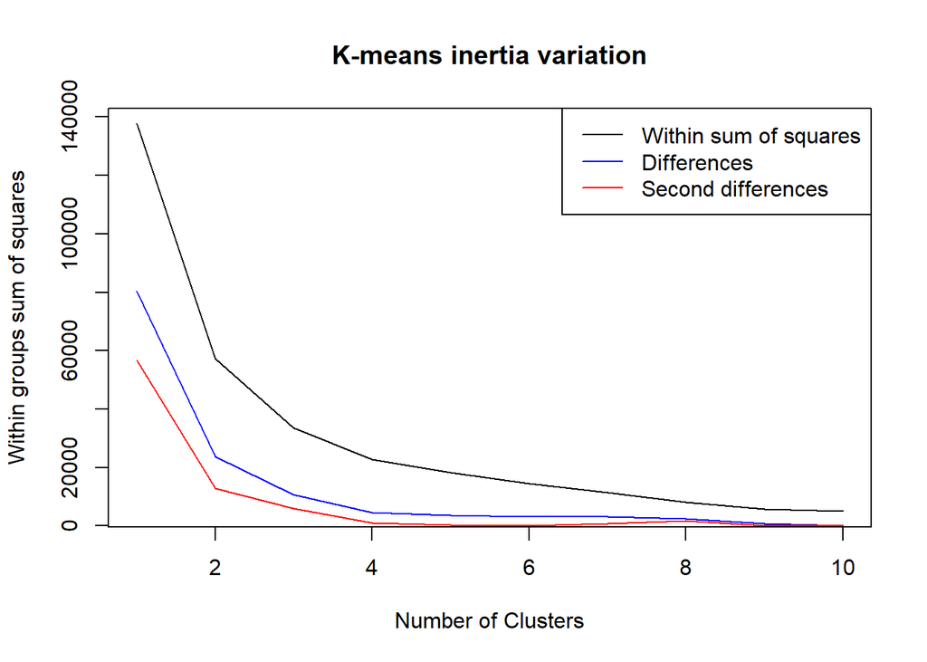

```r
# gráfico de los valores
plot(1:maxcl, index[,1], type="l", xlab="Number of Clusters",
     ylab="Within groups sum of squares", main = "K-means inertia variation")
  lines(1:maxcl, index[,2],col="blue")
  lines(1:maxcl, index[,3],col="red")
  legend("topright",legend=c("Within sum of squares","Differences","Second differences"),col=c("black","blue","red"),lty=1)
```

```r
dev.copy(pdf,"linnerud_kmeans_wss.pdf")
```

```r
dev.off()
```

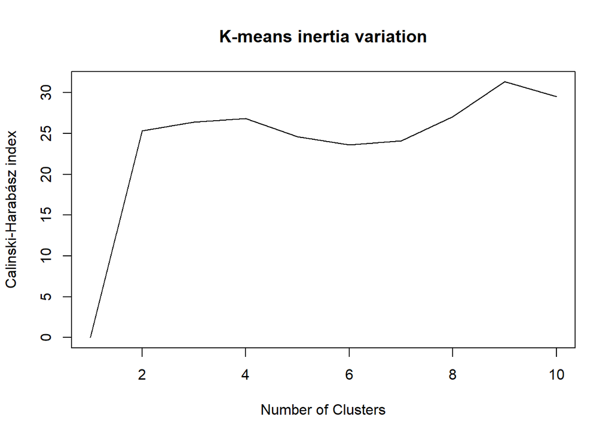

```r
plot(1:maxcl, index[,4], type="l", xlab="Number of Clusters",
     ylab="Calinski-Harabász index", main = "K-means inertia variation")
```

```r
dev.copy(pdf,"linnerud_kmeans_CH.pdf")
```

```r
dev.off()
```

```r
# kmeans con cuatro grupos y tres diferentes selecciones iniciales
dat.kcl <- kmeans(dat,centers=4,nstart=3)
dat.kcl
```

```
## K-means clustering with 4 clusters of sizes 6, 9, 4, 1
##
## Cluster means:
##       Peso  Cintura Pulsaciones Lanzamientos Flexiones    Saltos
## 1 168.5000 33.33333    59.66667    13.333333    215.00  88.83333
## 2 175.5556 35.33333    55.77778     8.111111    121.00  53.22222
## 3 206.7500 39.25000    51.50000     4.750000     70.25  36.00000
## 4 154.0000 33.00000    56.00000    17.000000    251.00 250.00000
##
## Clustering vector:
##  1  2  3  4  5  6  7  8  9 10 11 12 13 14 15 16 17 18 19 20
##  2  2  2  2  2  2  3  2  1  4  2  1  1  3  3  1  3  1  1  2
##
## Within cluster sum of squares by cluster:
## [1]  7328.333 10752.222  4728.000     0.000
##  (between_SS / total_SS =  83.4 %)
##
## Available components:
##
## [1] "cluster"      "centers"      "totss"        "withinss"     "tot.withinss"
## [6] "betweenss"    "size"         "iter"         "ifault"
```

```r
summary(dat.kcl)
```

```
##              Length Class  Mode
## cluster      20     -none- numeric
## centers      24     -none- numeric
## totss         1     -none- numeric
## withinss      4     -none- numeric
## tot.withinss  1     -none- numeric
## betweenss     1     -none- numeric
## size          4     -none- numeric
## iter          1     -none- numeric
## ifault        1     -none- numeric
```

```r
dat.kcl$cluster        # atribución de las unidades a las clases
```

```
##  1  2  3  4  5  6  7  8  9 10 11 12 13 14 15 16 17 18 19 20
##  2  2  2  2  2  2  3  2  1  4  2  1  1  3  3  1  3  1  1  2
```

```r
dat.kcl$centers        # promedios de caracteres en cada clase
```

```
##       Peso  Cintura Pulsaciones Lanzamientos Flexiones    Saltos
## 1 168.5000 33.33333    59.66667    13.333333    215.00  88.83333
## 2 175.5556 35.33333    55.77778     8.111111    121.00  53.22222
## 3 206.7500 39.25000    51.50000     4.750000     70.25  36.00000
## 4 154.0000 33.00000    56.00000    17.000000    251.00 250.00000
```

```r
dat.kcl$totss          # total sum of squares
```

```
## [1] 137631.5
```

```r
dat.kcl$tot.withinss   # total within sum of squares
```

```
## [1] 22808.56
```

```r
dat.kcl$betweenss      # between sum of squares
```

```
## [1] 114822.9
```

```r
dat.kcl$size           # tamaño de las clases
```

```
## [1] 6 9 4 1
```

```r
dat.kcl$iter           # número de iteraciones
```

```
## [1] 3
```

```r
dat.kcl$ifault
```

```
## [1] 0
```

# PREGUNTA 2

Con los datos de Iris, correr la clasificación k-means con 3 grupos.

**Solucion**

Se descargara el archivo Iris.csv a una carpeta local, luego se cargara el archivo y se mostrara la estructura de la data, la cual llamaremos **“iris”**, luego se muestra la tabla con las primeras 10 observaciones.

```r
# Carga de la data Iris
iris<- read.csv("F:/R IMCA/TAREA 8/DESCARGA_DATA/Iris.csv",header=TRUE,row.names=1)

# Verificar la estructura de los datos
str(iris)
```

```
## 'data.frame':    150 obs. of  5 variables:
##  $ Sepal.length: num  5.1 4.9 4.7 4.6 5 5.4 4.6 5 4.4 4.9 ...
##  $ Sepal.width : num  3.5 3 3.2 3.1 3.6 3.9 3.4 3.4 2.9 3.1 ...
##  $ Petal.length: num  1.4 1.4 1.3 1.5 1.4 1.7 1.4 1.5 1.4 1.5 ...
##  $ Petal.width : num  0.2 0.2 0.2 0.2 0.2 0.4 0.3 0.2 0.2 0.1 ...
##  $ Species     : chr  "setosa" "setosa" "setosa" "setosa" ...
```

```r
# Visualizar los primeros registros de los datos sin modificar
head(iris,n=10)
```

|  | Sepal.length | Sepal.width | Petal.length | Petal.width | Species |
| --- | --- | --- | --- | --- | --- |
| 1 | 5.1 | 3.5 | 1.4 | 0.2 | setosa |
| 2 | 4.9 | 3.0 | 1.4 | 0.2 | setosa |
| 3 | 4.7 | 3.2 | 1.3 | 0.2 | setosa |
| 4 | 4.6 | 3.1 | 1.5 | 0.2 | setosa |
| 5 | 5.0 | 3.6 | 1.4 | 0.2 | setosa |
| 6 | 5.4 | 3.9 | 1.7 | 0.4 | setosa |
| 7 | 4.6 | 3.4 | 1.4 | 0.3 | setosa |
| 8 | 5.0 | 3.4 | 1.5 | 0.2 | setosa |
| 9 | 4.4 | 2.9 | 1.4 | 0.2 | setosa |
| 10 | 4.9 | 3.1 | 1.5 | 0.1 | setosa |

```r
#pasame el dataframe a total, a solo usar las variable cuantitativas
iris.scale<-as.data.frame(iris[,1:4])

#Visualizacion de la data scalada
head(iris.scale,n=10)
```

|  | Sepal.length | Sepal.width | Petal.length | Petal.width |
| --- | --- | --- | --- | --- |
| 1 | 5.1 | 3.5 | 1.4 | 0.2 |
| 2 | 4.9 | 3.0 | 1.4 | 0.2 |
| 3 | 4.7 | 3.2 | 1.3 | 0.2 |
| 4 | 4.6 | 3.1 | 1.5 | 0.2 |
| 5 | 5.0 | 3.6 | 1.4 | 0.2 |
| 6 | 5.4 | 3.9 | 1.7 | 0.4 |
| 7 | 4.6 | 3.4 | 1.4 | 0.3 |
| 8 | 5.0 | 3.4 | 1.5 | 0.2 |
| 9 | 4.4 | 2.9 | 1.4 | 0.2 |
| 10 | 4.9 | 3.1 | 1.5 | 0.1 |

A continuacion plantamos la semilla de aleoteridad y aplicamos el la clasificacion k - means con tres cluster predifinidos

```r
#semilla de aleotariedad
set.seed(50)

#Hacemos clisificacion k-means
iris.km<-kmeans(iris.scale,centers = 3)
```

A continuacion presentamos los valores entregados por el modelo de clasificacion k-means.

```r
for(i in 1:1){
    cat("############# RESUMEN DE RESULTADOS  ###############\n")
    #contenido del objeto creado
    cat("\nContenido del objeto creado:\n",names(iris.km))

    #Asignacion observaciones a clusters
    cat("\nAsignacion observaciones a clusters:\n",iris.km$cluster)

    #Inercia Total
    cat("\nInercia Total:",iris.km$totss)

    #Inercia Inter Grupos
    cat("\nInercia Inter Grupos:",iris.km$betweenss)

    #Inercia Intra Grupos
    cat("\nInercia Intra Grupos por clusters:",iris.km$withinss)

    #Inercia Intra Grupos Total
    cat("\nInercia Intra Grupos Total",iris.km$tot.withinss)
}
```

```
## ############# RESUMEN DE RESULTADOS  ###############
##
## Contenido del objeto creado:
##  cluster centers totss withinss tot.withinss betweenss size iter ifault
## Asignacion observaciones a clusters:
##  2 2 2 2 2 2 2 2 2 2 2 2 2 2 2 2 2 2 2 2 2 2 2 2 2 2 2 2 2 2 2 2 2 2 2 2 2 2 2 2 2 2 2 2 2 2 2 2 2 2 3 1 3 3 3 3 1 3 3 3 3 3 3 1 1 3 3 3 3 1 3 1 3 1 3 3 1 1 3 3 3 3 3 1 3 3 3 3 1 3 3 3 1 3 3 3 1 3 3 1 1 1 3 1 1 1 1 1 1 1 1 1 1 1 1 1 1 1 1 1 1 1 1 1 1 1 1 3 1 1 1 1 1 1 1 1 1 1 1 1 1 1 1 1 1 1 1 1 …
## Inercia Total: 681.3706
## Inercia Inter Grupos: 602.5192
## Inercia Intra Grupos por clusters: 39.82097 15.151 23.87947
## Inercia Intra Grupos Total 78.85144
```

# PREGUNTA 3

¿Se corresponde a la clasificación en tres especies? Cuales flores están mal clasificados?

**Solucion**

Para responder la presente pregunta se hara una comparacion entre la data original iris en la cual ya esta claficada las especies contra la clasificacion que puede hacer el k-means. Es asi que coje la data con las variables cualitativas y se hace la clasificacion con el k-means. La data inicial iris tenemos 150 observaciones, las cuales estan clasificadas de la siguiente forma:

- De la observacion 001 - 050, corresponde a la especie Setosa, le pondremos etiqueta 2
- De la observacion 051 - 100, corresponde a la especie Virginica, le pondremos etiqueta 3
- De la observacion 101 - 150, corresponde a la especie Versicolor, le pondremos etiqueta 1

La data de clasificacio k-means tenemos 150 observaciones repartidas en 3 cluster, las cuales el algoritmo coloca etiquetas del 1 al 3, de la siguiente forma:

```r
#Asignacion observaciones a cluster
iris.km$cluster
```

```
##   1   2   3   4   5   6   7   8   9  10  11  12  13  14  15  16  17  18  19  20
##   2   2   2   2   2   2   2   2   2   2   2   2   2   2   2   2   2   2   2   2
##  21  22  23  24  25  26  27  28  29  30  31  32  33  34  35  36  37  38  39  40
##   2   2   2   2   2   2   2   2   2   2   2   2   2   2   2   2   2   2   2   2
##  41  42  43  44  45  46  47  48  49  50  51  52  53  54  55  56  57  58  59  60
##   2   2   2   2   2   2   2   2   2   2   3   1   3   3   3   3   1   3   3   3
##  61  62  63  64  65  66  67  68  69  70  71  72  73  74  75  76  77  78  79  80
##   3   3   3   1   1   3   3   3   3   1   3   1   3   1   3   3   1   1   3   3
##  81  82  83  84  85  86  87  88  89  90  91  92  93  94  95  96  97  98  99 100
##   3   3   3   1   3   3   3   3   1   3   3   3   1   3   3   3   1   3   3   1
## 101 102 103 104 105 106 107 108 109 110 111 112 113 114 115 116 117 118 119 120
##   1   1   3   1   1   1   1   1   1   1   1   1   1   1   1   1   1   1   1   1
## 121 122 123 124 125 126 127 128 129 130 131 132 133 134 135 136 137 138 139 140
##   1   1   1   1   1   1   1   3   1   1   1   1   1   1   1   1   1   1   1   1
## 141 142 143 144 145 146 147 148 149 150
##   1   1   1   1   1   1   1   1   1   1
```

Se hara un cuadro comparativo entre la data inicial iris, contra la data clasificada con k-means, esto para ver cual especie esta mal clasificado. En cuadro si la especie clasificada con k-mean coindice con la clasificacion original se pondra “0” en caso contrario sera “1”.

```r
x<-rbind(c(rep(2,50),rep(3,50),rep(1,50)),iris.km$cluster,rep(0,150))
x<-t(x)
y<-matrix(nrow=0,ncol=4)
for (i in 1:150) {
  if(x[i,1]!=x[i,2]){
    x[i,3]=1
    y<-rbind(y,c(i,x[i,1],x[i,2],x[i,3]))
  }
}
colnames(x)<-c("Data Iris","Iris K-means","Diferencias")
colnames(y)<-c("Obser N°","Data Iris","Iris K-means","Diferencias")
print(x)
```

```
##     Data Iris Iris K-means Diferencias
## 1           2            2           0
## 2           2            2           0
## 3           2            2           0
## 4           2            2           0
## 5           2            2           0
## 6           2            2           0
## 7           2            2           0
## 8           2            2           0
## 9           2            2           0
## 10          2            2           0
## 11          2            2           0
## 12          2            2           0
## 13          2            2           0
## 14          2            2           0
```

[output cut: 136 more lines]

De los resultados, tenemos un error de 16/150=10.66% de predicion o que esta mal clasificado inicialmente. La clasificacion de K-mean nos indica que las siguientes observaciones estan mal clasificadas. Se observa de la tabla que la que tiene problemas en la clasificacion es en la especie con etiqueta 3 de la data original Iris la cual corresponde a la especie Virginia, las cuales estan siendo clasificadas con el K-means como especie de etiqueta 1 la cual corresponde a la especie Versicolor.

```r
#Impresion de la tabla con las diferencias en la clasificacion
print(y)
```

```
##       Obser N° Data Iris Iris K-means Diferencias
##  [1,]       52         3            1           1
##  [2,]       57         3            1           1
##  [3,]       64         3            1           1
##  [4,]       65         3            1           1
##  [5,]       70         3            1           1
##  [6,]       72         3            1           1
##  [7,]       74         3            1           1
##  [8,]       77         3            1           1
##  [9,]       78         3            1           1
## [10,]       84         3            1           1
## [11,]       89         3            1           1
## [12,]       93         3            1           1
## [13,]       97         3            1           1
## [14,]      100         3            1           1
## [15,]      103         1            3           1
## [16,]      128         1            3           1
```

# PREGUNTA 4

Calcular la razón de correlación y su tabla de “breakdown” sobre los tres grupos resultantes de la clasificación.

**Solucion**

Luego de la clasificacion tenemos tres agrupamientos que hace el algoritmo, los cuales pasamos a identificar segun la data original. El criterio es el siguiente:

- Grupo 1, el cual corresponde a la especie versicolor
- Grupo 2, el cual corresponde a la especie setosa
- Grupo 3, el cual corresponde a la especie virginica

A continuacion se pasara a pasar las etiquetas segun el critero anteriormenente mencionado:

```r
#asignacion del criterio de agrupamiento del kmeans a la data original
iris.scale$grupo <- as.factor(iris.km$cluster)

#mostrando el dataframe antes del cambio de etiquetas.
head(iris.scale,n=10)
```

|  | Sepal.length | Sepal.width | Petal.length | Petal.width | grupo |
| --- | --- | --- | --- | --- | --- |
| 1 | 5.1 | 3.5 | 1.4 | 0.2 | 2 |
| 2 | 4.9 | 3.0 | 1.4 | 0.2 | 2 |
| 3 | 4.7 | 3.2 | 1.3 | 0.2 | 2 |
| 4 | 4.6 | 3.1 | 1.5 | 0.2 | 2 |
| 5 | 5.0 | 3.6 | 1.4 | 0.2 | 2 |
| 6 | 5.4 | 3.9 | 1.7 | 0.4 | 2 |
| 7 | 4.6 | 3.4 | 1.4 | 0.3 | 2 |
| 8 | 5.0 | 3.4 | 1.5 | 0.2 | 2 |
| 9 | 4.4 | 2.9 | 1.4 | 0.2 | 2 |
| 10 | 4.9 | 3.1 | 1.5 | 0.1 | 2 |

Se pasara a tranformar el dataframe para que tenga las etiquetas de la clasificacion y poder ver mas detalle del agrupamiento de la data:

```r
# Cambiar la columna 'columna_factor' de factor a character basándote en un criterio de comparación término por término
iris.scale$grupo <- sapply(iris.scale$grupo, function(x) {
  if (x == "1") {
    return("versicolor")
  } else if (x == "2") {
    return("setosa")
  } else {
    return("virginica")
  }
})

# Convertir a character
iris.scale$grupo <- as.character(iris.scale$grupo)

# Mostrar el dataframe después del cambio
print(iris.scale)
```

```
##     Sepal.length Sepal.width Petal.length Petal.width      grupo
## 1            5.1         3.5          1.4         0.2     setosa
## 2            4.9         3.0          1.4         0.2     setosa
## 3            4.7         3.2          1.3         0.2     setosa
## 4            4.6         3.1          1.5         0.2     setosa
## 5            5.0         3.6          1.4         0.2     setosa
## 6            5.4         3.9          1.7         0.4     setosa
## 7            4.6         3.4          1.4         0.3     setosa
## 8            5.0         3.4          1.5         0.2     setosa
## 9            4.4         2.9          1.4         0.2     setosa
## 10           4.9         3.1          1.5         0.1     setosa
## 11           5.4         3.7          1.5         0.2     setosa
## 12           4.8         3.4          1.6         0.2     setosa
## 13           4.8         3.0          1.4         0.1     setosa
## 14           4.3         3.0          1.1         0.1     setosa
```

[output cut: 136 more lines]

Se hara la tabla breakdown sobre los tres grupos resultantes de la clasificación.

```r
#Total de observaciones de la variable 1
n_t = length(iris.scale[,1])

#Media de las observaciones de la variable 1
m_t = mean(iris.scale[,1])

#Varianza de las observaciones de la variable 1
v_t = var(iris.scale[,1])*(n_t-1)/n_t

#Desviacon Standar de las observaciones de la variable 1
s_t = sqrt(v_t)

#Coeficiente de variacion de las observaciones de la variable 1
cvt = s_t/m_t

#Agrupamiento de las estadisticas totales
total=rbind(n_t,m_t,v_t,s_t,cvt)

#Estadisticas por varible categorica (Variable 5)
n_unit=table(iris.scale[,5])

#MEdia por categorica (Variable 5)
mean=tapply(iris.scale[,1],iris.scale[,5],mean)

#Varianza por categorica (Variable 5)
var=tapply(iris.scale[,1],iris.scale[,5],var)
var=var*(n_unit-1)/n_unit

#Desviacion Standar por categorica (Variable 5)
stdev=sqrt(var)
cv=stdev/mean

#Agrupamiento de las estadisticas parciales por variable categorica
brk=rbind(n_unit,mean,var,stdev,cv)

#Agrupamiento de la estadisticas por categoria (Var 5) contra la estadistica global(var 1)
brtot=cbind(brk,total)
colnames(brtot) = c(colnames(brk),"total")
brtot
```

```
##             setosa  versicolor   virginica       total
## n_unit 50.00000000 62.00000000 38.00000000 150.0000000
## mean    5.00600000  5.90161290  6.85000000   5.8433333
## var     0.12176400  0.21402966  0.23776316   0.6811222
## stdev   0.34894699  0.46263339  0.48760964   0.8253013
## cv      0.06970575  0.07839101  0.07118389   0.1412381
```

La razon de correlacion sera:

```r
#La razón de correlación se puede calcular en dos maneras bajo esta tabla
e = sum(n_unit*(mean-m_t)^2) / (n_t*v_t)
cat("Razon de correlacion(e):",e)
```

```
## Razon de correlacion(e): 0.7220955
```

Se presenta el diagrama de cajas con los datos clasificados con el algoritmo kmeans:

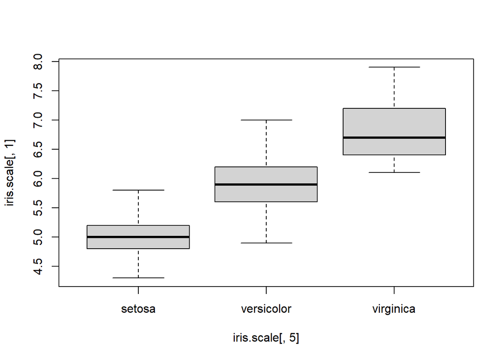

```r
boxplot(iris.scale[,1]~iris.scale[,5])
```

# PREGUNTA 5

Aplicando el K-means entre 1 y 10 clases, ¿cual parece la partición mejor?

**Solucion**

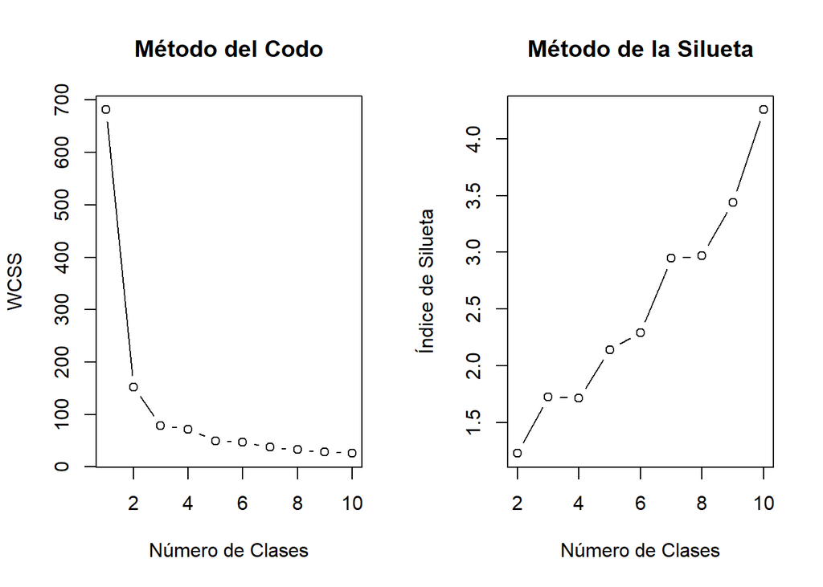

```r
# Cargar biblioteca necesaria
library(cluster)

# Supongamos que tienes un dataframe llamado 'datos'

# Calcular la suma de cuadrados dentro de grupos (WCSS) para un número variable de clases
wcss <- sapply(1:10, function(k) {
  kmeans(iris.scale[,1:4], centers = k)$tot.withinss
})

# Calcular el índice de la silueta para un número variable de clases
silhouette <- sapply(2:10, function(k) {
  mean(silhouette(kmeans(iris.scale[,1:4], centers = k)$cluster, dist(iris.scale[,1:4])))
})

# Graficar WCSS y el índice de la silueta para evaluar el número óptimo de clases
par(mfrow = c(1, 2))
plot(1:10, wcss, type = "b", xlab = "Número de Clases", ylab = "WCSS", main = "Método del Codo")
plot(2:10, silhouette, type = "b", xlab = "Número de Clases", ylab = "Índice de Silueta", main = "Método de la Silueta")
```

El criterio del método del codo en K-means se basa en la observación de la disminución en la suma de cuadrados dentro del cluster (WCSS) a medida que aumenta el número de clusters. La idea es encontrar el punto en el gráfico de WCSS versus el número de clusters donde la disminución de la WCSS se desacelera significativamente, formando lo que se denomina el “codo”. Este punto se considera como una indicación del número óptimo de clusters para el conjunto de datos. Para nuestro caso seria entre 2 y 3 el numero de clusters.

# PREGUNTA 6

Estandarizar los datos de Iris, empleando el comando scale(X, center=TRUE,scale=TRUE), con X el archivo Iris, limitadamente a las cuatro mediciones, y re-correr el k-means.

**Solucion**

Se cargara la data iris y lo scalaremos con el comando *scale*.

```r
#Escalamos las varibales
iris.scale<-as.data.frame(scale(iris[,1:4]))

#Visualizacion de la data scalada
head(iris.scale,n=10)
```

|  | Sepal.length | Sepal.width | Petal.length | Petal.width |
| --- | --- | --- | --- | --- |
| 1 | -0.8976739 | 1.01560199 | -1.335752 | -1.311052 |
| 2 | -1.1392005 | -0.13153881 | -1.335752 | -1.311052 |
| 3 | -1.3807271 | 0.32731751 | -1.392399 | -1.311052 |
| 4 | -1.5014904 | 0.09788935 | -1.279104 | -1.311052 |
| 5 | -1.0184372 | 1.24503015 | -1.335752 | -1.311052 |
| 6 | -0.5353840 | 1.93331463 | -1.165809 | -1.048667 |
| 7 | -1.5014904 | 0.78617383 | -1.335752 | -1.179859 |
| 8 | -1.0184372 | 0.78617383 | -1.279104 | -1.311052 |
| 9 | -1.7430170 | -0.36096697 | -1.335752 | -1.311052 |
| 10 | -1.1392005 | 0.09788935 | -1.279104 | -1.442245 |

A continuacion plantamos la semilla de aleoteridad y aplicamos el la clasificacion k - means con tres cluster predifinidos

```r
#semilla de aleotariedad
set.seed(50)

#Hacemos clisificacion k-means
iris.km<-kmeans(iris.scale,centers = 3)
```

A continuacion presentamos los valores entregados por el modelo de clasificacion k-means.

```r
for(i in 1:1){
    cat("############# RESUMEN DE RESULTADOS  ###############\n")
    #contenido del objeto creado
    cat("\nContenido del objeto creado:\n",names(iris.km))
    cat("\n")
    #Asignacion observaciones a cluster
    #cat("\nAsignacion observaciones a clusters:\n",iris.km$cluster)
    print(iris.km$cluster)

    #Inercia Total
    cat("\nInercia Total:",iris.km$totss)

    #Inercia Inter Grupos
    cat("\nInercia Inter Grupos:",iris.km$betweenss)

    #Inercia Intra Grupos
    cat("\nInercia Intra Grupos por clusters:",iris.km$withinss)

    #Inercia Intra Grupos Total
    cat("\nInercia Intra Grupos Total",iris.km$tot.withinss)
}
```

```
## ############# RESUMEN DE RESULTADOS  ###############
##
## Contenido del objeto creado:
##  cluster centers totss withinss tot.withinss betweenss size iter ifault
##   1   2   3   4   5   6   7   8   9  10  11  12  13  14  15  16  17  18  19  20
##   2   2   2   2   2   2   2   2   2   2   2   2   2   2   2   2   2   2   2   2
##  21  22  23  24  25  26  27  28  29  30  31  32  33  34  35  36  37  38  39  40
##   2   2   2   2   2   2   2   2   2   2   2   2   2   2   2   2   2   2   2   2
##  41  42  43  44  45  46  47  48  49  50  51  52  53  54  55  56  57  58  59  60
##   2   2   2   2   2   2   2   2   2   2   1   3   1   1   1   1   3   1   1   1
##  61  62  63  64  65  66  67  68  69  70  71  72  73  74  75  76  77  78  79  80
##   1   1   1   3   3   1   1   1   1   3   1   3   1   3   1   1   3   1   1   1
##  81  82  83  84  85  86  87  88  89  90  91  92  93  94  95  96  97  98  99 100
##   1   1   1   3   3   1   1   1   3   1   1   1   3   1   1   1   3   1   1   3
## 101 102 103 104 105 106 107 108 109 110 111 112 113 114 115 116 117 118 119 120
##   1   1   1   3   3   3   1   3   3   3   3   3   3   3   3   1   3   3   3   3
## 121 122 123 124 125 126 127 128 129 130 131 132 133 134 135 136 137 138 139 140
##   1   3   3   3   3   1   1   1   3   3   3   3   3   3   3   1   1   3   3   3
## 141 142 143 144 145 146 147 148 149 150
##   3   3   3   3   3   3   3   3   3   3
##
## Inercia Total: 596
## Inercia Inter Grupos: 457.1116
## Inercia Intra Grupos por clusters: 47.45019 47.35062 44.08754
## Inercia Intra Grupos Total 138.8884
```

# PREGUNTA 7

¿Se encuentran resultados mejores o peores? (para el breakdown, solo emplear la clasificación salida, pero siempre las mediciones de Iris).

**Solucion**

Luego de la clasificacion tenemos tres agrupamientos que hace el algoritmo pero con la data escalada, los cuales pasamos a identificar segun la data original. El criterio es el siguiente:

A continuacion se pasara a pasar las etiquetas segun el critero anteriormenente mencionado:

```r
#asignacion del criterio de agrupamiento del kmeans a la data original
iris.scale$grupo <- as.factor(iris.km$cluster)

#mostrando el dataframe antes del cambio de etiquetas.
head(iris.scale,n=10)
```

|  | Sepal.length | Sepal.width | Petal.length | Petal.width | grupo |
| --- | --- | --- | --- | --- | --- |
| 1 | -0.8976739 | 1.01560199 | -1.335752 | -1.311052 | 2 |
| 2 | -1.1392005 | -0.13153881 | -1.335752 | -1.311052 | 2 |
| 3 | -1.3807271 | 0.32731751 | -1.392399 | -1.311052 | 2 |
| 4 | -1.5014904 | 0.09788935 | -1.279104 | -1.311052 | 2 |
| 5 | -1.0184372 | 1.24503015 | -1.335752 | -1.311052 | 2 |
| 6 | -0.5353840 | 1.93331463 | -1.165809 | -1.048667 | 2 |
| 7 | -1.5014904 | 0.78617383 | -1.335752 | -1.179859 | 2 |
| 8 | -1.0184372 | 0.78617383 | -1.279104 | -1.311052 | 2 |
| 9 | -1.7430170 | -0.36096697 | -1.335752 | -1.311052 | 2 |
| 10 | -1.1392005 | 0.09788935 | -1.279104 | -1.442245 | 2 |

Se pasara a tranformar el dataframe para que tenga las etiquetas de la clasificacion y poder ver mas detalle del agrupamiento de la data:

```r
# Cambiar la columna 'columna_factor' de factor a character basándote en un criterio de comparación término por término
iris.scale$grupo <- sapply(iris.scale$grupo, function(x) {
  if (x == "1") {
    return("versicolor")
  } else if (x == "2") {
    return("setosa")
  } else {
    return("virginica")
  }
})

# Convertir a character
iris.scale$grupo <- as.character(iris.scale$grupo)

# Mostrar el dataframe después del cambio
print(iris.scale)
```

```
##     Sepal.length Sepal.width Petal.length   Petal.width      grupo
## 1    -0.89767388  1.01560199  -1.33575163 -1.3110521482     setosa
## 2    -1.13920048 -0.13153881  -1.33575163 -1.3110521482     setosa
## 3    -1.38072709  0.32731751  -1.39239929 -1.3110521482     setosa
## 4    -1.50149039  0.09788935  -1.27910398 -1.3110521482     setosa
## 5    -1.01843718  1.24503015  -1.33575163 -1.3110521482     setosa
## 6    -0.53538397  1.93331463  -1.16580868 -1.0486667950     setosa
## 7    -1.50149039  0.78617383  -1.33575163 -1.1798594716     setosa
## 8    -1.01843718  0.78617383  -1.27910398 -1.3110521482     setosa
## 9    -1.74301699 -0.36096697  -1.33575163 -1.3110521482     setosa
## 10   -1.13920048  0.09788935  -1.27910398 -1.4422448248     setosa
## 11   -0.53538397  1.47445831  -1.27910398 -1.3110521482     setosa
## 12   -1.25996379  0.78617383  -1.22245633 -1.3110521482     setosa
## 13   -1.25996379 -0.13153881  -1.33575163 -1.4422448248     setosa
## 14   -1.86378030 -0.13153881  -1.50569459 -1.4422448248     setosa
```

[output cut: 136 more lines]

Se hara la tabla breakdown sobre los tres grupos resultantes de la clasificación.

```r
#Total de observaciones de la variable 1
n_t = length(iris.scale[,1])

#Media de las observaciones de la variable 1
m_t = mean(iris.scale[,1])

#Varianza de las observaciones de la variable 1
v_t = var(iris.scale[,1])*(n_t-1)/n_t

#Desviacon Standar de las observaciones de la variable 1
s_t = sqrt(v_t)

#Coeficiente de variacion de las observaciones de la variable 1
cvt = s_t/m_t

#Agrupamiento de las estadisticas totales
total=rbind(n_t,m_t,v_t,s_t,cvt)

#Estadisticas por varible categorica (Variable 5)
n_unit=table(iris.scale[,5])

#MEdia por categorica (Variable 5)
mean=tapply(iris.scale[,1],iris.scale[,5],mean)

#Varianza por categorica (Variable 5)
var=tapply(iris.scale[,1],iris.scale[,5],var)
var=var*(n_unit-1)/n_unit

#Desviacion Standar por categorica (Variable 5)
stdev=sqrt(var)
cv=stdev/mean

#Agrupamiento de las estadisticas parciales por variable categorica
brk=rbind(n_unit,mean,var,stdev,cv)

#Agrupamiento de la estadisticas por categoria (Var 5) contra la estadistica global(var 1)
brtot=cbind(brk,total)
colnames(brtot) = c(colnames(brk),"total")
brtot
```

```
##            setosa versicolor   virginica         total
## n_unit 50.0000000 47.0000000 53.00000000  1.500000e+02
## mean   -1.0111914  1.1321774 -0.05005221 -4.482842e-16
## var     0.1775779  0.3435803  0.23526137  9.933333e-01
## stdev   0.4213999  0.5861572  0.48503749  9.966611e-01
## cv     -0.4167361  0.5177256 -9.69063063 -2.223280e+15
```

Observamos que los coeficiente de variacion han crecido. Un coeficiente de variación alto indica una gran variabilidad relativa en relación con la media. Esto puede implicar que los datos tienen una dispersión significativa en comparación con su valor medio. En otras palabras, los valores individuales en el conjunto de datos pueden ser muy diferentes entre sí en comparación con la media. Es decir al subir el coeficiente de variación puede indicar una inconsistencia significativa en la calidad de los datos agrupados. Por esta razon se podemos decir que los resultados empeoran con el escalamiento.

# PREGUNTA 8

Hacer lo mismo con datos de Linnerud, pero intentando diferentes clasificaciones y el índice CH, tanto para los datos brutos, como para los estandarizados.

**Solucion**

Primero iniciamos leyendo el archivos sin escalamiento:

```r
# Carga de la data Linnerud
linnerSinEscalar <- read.csv("F:/R IMCA/TAREA 8/DESCARGA_DATA/Linnerud.csv",header=TRUE,row.names=1)

#Visualizacion de la data sin escalar
head(linnerud,n=10)
```

|  | Peso | Cintura | Pulsaciones | Lanzamientos | Flexiones | Saltos |
| --- | --- | --- | --- | --- | --- | --- |
| 1 | 191 | 36 | 50 | 5 | 162 | 60 |
| 2 | 189 | 37 | 52 | 2 | 110 | 60 |
| 3 | 193 | 38 | 58 | 12 | 101 | 101 |
| 4 | 162 | 35 | 62 | 12 | 105 | 37 |
| 5 | 189 | 35 | 46 | 13 | 155 | 58 |
| 6 | 182 | 36 | 56 | 4 | 101 | 42 |
| 7 | 211 | 38 | 56 | 8 | 101 | 38 |
| 8 | 167 | 34 | 60 | 6 | 125 | 40 |
| 9 | 176 | 31 | 74 | 15 | 200 | 40 |
| 10 | 154 | 33 | 56 | 17 | 251 | 250 |

Pasamos a escalar la data original,para hacer correr el algoritmo K-means:

```r
#Escalamos las varibales
linnerud<-as.data.frame(scale(linnerSinEscalar[,1:6]))

# Verificar la estructura de los datos
str(linnerud)
```

```
## 'data.frame':    20 obs. of  6 variables:
##  $ Peso        : num  0.502 0.421 0.583 -0.672 0.421 ...
##  $ Cintura     : num  0.187 0.5 0.812 -0.125 -0.125 ...
##  $ Pulsaciones : num  -0.846 -0.569 0.264 0.818 -1.401 ...
##  $ Lanzamientos: num  -0.842 -1.409 0.482 0.482 0.672 ...
##  $ Flexiones   : num  0.263 -0.568 -0.712 -0.648 0.151 ...
##  $ Saltos      : num  -0.201 -0.201 0.599 -0.649 -0.24 ...
```

```r
#Visualizacion de la data scalada
head(linnerud,n=10)
```

|  | Peso | Cintura | Pulsaciones | Lanzamientos | Flexiones | Saltos |
| --- | --- | --- | --- | --- | --- | --- |
| 1 | 0.5022173 | 0.1873845 | -0.84600343 | -0.8418021 | 0.2629199 | -0.2008679 |
| 2 | 0.4212145 | 0.4996919 | -0.56862526 | -1.4093091 | -0.5681948 | -0.2008679 |
| 3 | 0.5832201 | 0.8119993 | 0.26350927 | 0.4823810 | -0.7120415 | 0.5987035 |
| 4 | -0.6723232 | -0.1249230 | 0.81826561 | 0.4823810 | -0.6481096 | -0.6494080 |
| 5 | 0.4212145 | -0.1249230 | -1.40075978 | 0.6715500 | 0.1510391 | -0.2398714 |
| 6 | 0.1377048 | 0.1873845 | -0.01386891 | -1.0309711 | -0.7120415 | -0.5518993 |
| 7 | 1.3122453 | 0.8119993 | -0.01386891 | -0.2742951 | -0.7120415 | -0.6299063 |
| 8 | -0.4698162 | -0.4372304 | 0.54088744 | -0.6526331 | -0.3284501 | -0.5909028 |
| 9 | -0.1053036 | -1.3741527 | 2.48253466 | 1.0498880 | 0.8702730 | -0.5909028 |
| 10 | -0.9963344 | -0.7495378 | -0.01386891 | 1.4282260 | 1.6854047 | 3.5044631 |

```r
# Análisis con k- means

#  inicialización
dat      <- linnerud

#numero de observaciones (numero filas)
n        <- dim(dat)[1]

#numero de variables cuantitativas
p        <- dim(dat)[2]
maxcl    <- round(n/2,0)
wss      <- rep(0,maxcl)
wssd     <- wss
wssd2    <- wss
CH       <- wss
wss[1]   <- (n-1)*sum(apply(dat,2,var))

#  varios tentativos con varias clases
for (i in 1:maxcl) {
  wss[i] <- sum(kmeans(dat,centers=i)$withinss);       # colectando la ssw
  if (i>1) {
    wssd[i-1]  <- wss[i-1]-wss[i]
    CH[i] <- ((wss[1] - wss[i])/(i-1))/(wss[i]/(n-i))  # calculando el índice
  }                                                    # de Calinski-Harabász
  if (i>2) wssd2[i-2] <- wssd[i-2]-wssd[i-1]           # pero también diferencias
}
index2             <- cbind(wss,wssd,wssd2,CH)
rownames(index2)   <- c(1:maxcl)
colnames(index2)   <- c("SSW","D","D2","CH")

for(i in 1:1){
  cat("Tabla con la data bruta\n")
  print(index)
}
```

```
## Tabla con la data bruta
##           SSW          D          D2       CH
## 1  137631.500 80471.8516 56825.88511  0.00000
## 2   57159.648 23645.9665 12940.84027 25.34119
## 3   33513.682 10705.1263  6093.93737 26.40717
## 4   22808.556  4611.1889  1005.29841 26.84909
## 5   18197.367  3605.8905   362.29762 24.61224
## 6   14591.476  3243.5929    95.92619 23.61050
## 7   11347.883  3147.6667   733.86667 24.11150
## 8    8200.217  2413.8000  1619.38333 27.05809
## 9    5786.417   794.4167     0.00000 31.32975
## 10   4992.000     0.0000     0.00000 29.52268
```

```r
for(i in 1:1){
  cat("Tabla con la data Estandarizada\n")
  print(index2)
}
```

```
## Tabla con la data Estandarizada
##          SSW         D         D2        CH
## 1  114.00000 25.677382  -6.694571  0.000000
## 2   88.32262 32.371953  19.431740  5.233007
## 3   55.95066 12.940213   9.288528  8.818829
## 4   43.01045  3.651685  -1.437338  8.802766
## 5   39.35877  5.089023  -7.828676  7.111621
## 6   34.26974 12.917699   6.806461  6.514339
## 7   21.35204  6.111238   9.459884  9.401313
## 8   15.24081 -3.348646 -11.728011 11.108434
## 9   18.58945  8.379365   0.000000  7.057202
## 10  10.21009  0.000000   0.000000 11.294922
```

# PREGUNTA 9

¿Cual clasificación le parece mejor?